# Mobile Price Analysis

Statistical Laboratory

Sameer Afzal - University of Catania

## Description

One of the companies wants to started his own mobile company. they wants to give tough fight to big companies like Apple, Samsung, etc. They does not know how to estimate price of mobiles his company creates. In this competitive mobile phone market you cannot simply assume things. To solve this problem they collects sales data of mobile phones of various companies.

## **1. Packages and Loading Data set**

There are some data sets that are already pre-installed in R. Here, we shall be using external **Mobile Price Classification** data set that not comes built-in R Package.

While using any external data source, we can use the read command to load the files(Excel, CSV, HTML and text files etc.)

This data set is also available at [Kaggle](https://www.kaggle.com/datasets/iabhishekofficial/mobile-price-classification). You may download the data set, both train and test files. In this analysis, we’d be just using the train data set.

```r
library(magrittr)
library(dplyr)
```

```r
library(ggplot2)
library(pacman)
library(nnet)
pacman::p_load(pacman, dplyr, ggplot2, rio, gridExtra, scales, ggcorrplot, caret)
```

```r
data = read.csv("C:\\Users\\samee\\OneDrive\\Desktop\\Satistic lab\\presentation\\train.csv")
```

The above code reads the file train.csv into a dataframe **data**.

## **2. Understanding the Data set**

We have used the Mobile Price data set that contains records of 2000 mobiles with different spec . Below is a brief description of the 21 variables in the data set :

- battery_power = Total energy a battery can store in one time measured in mAh.
- blue = Has bluetooth or not. | 1: Has , 0: doesn’t have
- clock_speed = Speed at which microprocessor executes instructions.
- dual_sim = Has dual sim support or not | 1: support , 0: doesn’t support
- fc = Front Camera mega pixels.
- four_g= Has 4G or not. | 1: Has , 0: doesn’t have
- int_memory= Internal memory in gigabytes.
- m_dep = Mobile Depth in cm
- mobile_wt = Weight of mobile phone.
- n_cores = Number of cores of processor.
- pc = primary camera mega pixels.
- px_height = Pixel Resolution Height.
- px_width = Pixel Resolution Width.
- ram = Random Access Memory in Mega Bytes.
- sc_h = Screen Height of mobile in cm
- sc_w = Screen Width of mobile in cm
- talk_time = Longest time that a single battery charge will last when you are.
- three_g = Has 3G or not. | 1: Has, 0: Doesn’t have
- touch_screen = Has touch screen or not. | 1: Has, 0: Doesn’t have
- wifi = Has WiFi or not. | 1: Has, 0: Doesn’t have
- price_range = This is the target variable. | 3: Very High Cost, 2: High Cost, 1: Medium Cost, 0: Low Cost

## 2.1 Peek at your Data

Before we begin working on the dataset, let’s have a good look at the raw data.

**names() : This helps us in checking out all the variables in the data set.**

```r
names(data)
```

```
##  [1] "battery_power" "blue"          "clock_speed"   "dual_sim"
##  [5] "fc"            "four_g"        "int_memory"    "m_dep"
##  [9] "mobile_wt"     "n_cores"       "pc"            "px_height"
## [13] "px_width"      "ram"           "sc_h"          "sc_w"
## [17] "talk_time"     "three_g"       "touch_screen"  "wifi"
## [21] "price_range"
```

**In order to have a quick look at the data, we often use the head()/tail().**

```r
head(data)
```

```
##   battery_power blue clock_speed dual_sim fc four_g int_memory m_dep mobile_wt
## 1           842    0         2.2        0  1      0          7   0.6       188
## 2          1021    1         0.5        1  0      1         53   0.7       136
## 3           563    1         0.5        1  2      1         41   0.9       145
## 4           615    1         2.5        0  0      0         10   0.8       131
## 5          1821    1         1.2        0 13      1         44   0.6       141
## 6          1859    0         0.5        1  3      0         22   0.7       164
##   n_cores pc px_height px_width  ram sc_h sc_w talk_time three_g touch_screen
## 1       2  2        20      756 2549    9    7        19       0            0
## 2       3  6       905     1988 2631   17    3         7       1            1
## 3       5  6      1263     1716 2603   11    2         9       1            1
## 4       6  9      1216     1786 2769   16    8        11       1            0
## 5       2 14      1208     1212 1411    8    2        15       1            1
## 6       1  7      1004     1654 1067   17    1        10       1            0
##   wifi price_range
## 1    1           1
## 2    0           2
## 3    0           2
## 4    0           2
## 5    0           1
## 6    0           1
```

```r
tail(data)
```

```
##      battery_power blue clock_speed dual_sim fc four_g int_memory m_dep
## 1995           858    0         2.2        0  1      0         50   0.1
## 1996           794    1         0.5        1  0      1          2   0.8
## 1997          1965    1         2.6        1  0      0         39   0.2
## 1998          1911    0         0.9        1  1      1         36   0.7
## 1999          1512    0         0.9        0  4      1         46   0.1
## 2000           510    1         2.0        1  5      1         45   0.9
##      mobile_wt n_cores pc px_height px_width  ram sc_h sc_w talk_time three_g
## 1995        84       1  2       528     1416 3978   17   16         3       1
## 1996       106       6 14      1222     1890  668   13    4        19       1
## 1997       187       4  3       915     1965 2032   11   10        16       1
## 1998       108       8  3       868     1632 3057    9    1         5       1
## 1999       145       5  5       336      670  869   18   10        19       1
## 2000       168       6 16       483      754 3919   19    4         2       1
##      touch_screen wifi price_range
## 1995            1    0           3
## 1996            1    0           0
## 1997            1    1           2
## 1998            1    0           3
## 1999            1    1           0
## 2000            1    1           3
```

**str() :** This helps in understanding the structure of the data set, data type of each attribute and number of rows and columns present in the data.

```r
str(data)
```

```
## 'data.frame':    2000 obs. of  21 variables:
##  $ battery_power: int  842 1021 563 615 1821 1859 1821 1954 1445 509 ...
##  $ blue         : int  0 1 1 1 1 0 0 0 1 1 ...
##  $ clock_speed  : num  2.2 0.5 0.5 2.5 1.2 0.5 1.7 0.5 0.5 0.6 ...
##  $ dual_sim     : int  0 1 1 0 0 1 0 1 0 1 ...
##  $ fc           : int  1 0 2 0 13 3 4 0 0 2 ...
##  $ four_g       : int  0 1 1 0 1 0 1 0 0 1 ...
##  $ int_memory   : int  7 53 41 10 44 22 10 24 53 9 ...
##  $ m_dep        : num  0.6 0.7 0.9 0.8 0.6 0.7 0.8 0.8 0.7 0.1 ...
##  $ mobile_wt    : int  188 136 145 131 141 164 139 187 174 93 ...
##  $ n_cores      : int  2 3 5 6 2 1 8 4 7 5 ...
##  $ pc           : int  2 6 6 9 14 7 10 0 14 15 ...
##  $ px_height    : int  20 905 1263 1216 1208 1004 381 512 386 1137 ...
##  $ px_width     : int  756 1988 1716 1786 1212 1654 1018 1149 836 1224 ...
##  $ ram          : int  2549 2631 2603 2769 1411 1067 3220 700 1099 513 ...
##  $ sc_h         : int  9 17 11 16 8 17 13 16 17 19 ...
##  $ sc_w         : int  7 3 2 8 2 1 8 3 1 10 ...
##  $ talk_time    : int  19 7 9 11 15 10 18 5 20 12 ...
##  $ three_g      : int  0 1 1 1 1 1 1 1 1 1 ...
##  $ touch_screen : int  0 1 1 0 1 0 0 1 0 0 ...
##  $ wifi         : int  1 0 0 0 0 0 1 1 0 0 ...
##  $ price_range  : int  1 2 2 2 1 1 3 0 0 0 ...
```

**summary():** is one of the most important functions that help in summarising each attribute in the dataset. It gives a set of descriptive statistics, depending on the type of variable:

In case we just need the summary statistic for a particular variable in the dataset, we can use **summary(datasetName$VariableName)**

```r
summary(data)
```

```
##  battery_power         blue        clock_speed       dual_sim
##  Min.   : 501.0   Min.   :0.000   Min.   :0.500   Min.   :0.0000
##  1st Qu.: 851.8   1st Qu.:0.000   1st Qu.:0.700   1st Qu.:0.0000
##  Median :1226.0   Median :0.000   Median :1.500   Median :1.0000
##  Mean   :1238.5   Mean   :0.495   Mean   :1.522   Mean   :0.5095
##  3rd Qu.:1615.2   3rd Qu.:1.000   3rd Qu.:2.200   3rd Qu.:1.0000
##  Max.   :1998.0   Max.   :1.000   Max.   :3.000   Max.   :1.0000
##        fc             four_g         int_memory        m_dep
##  Min.   : 0.000   Min.   :0.0000   Min.   : 2.00   Min.   :0.1000
##  1st Qu.: 1.000   1st Qu.:0.0000   1st Qu.:16.00   1st Qu.:0.2000
##  Median : 3.000   Median :1.0000   Median :32.00   Median :0.5000
##  Mean   : 4.309   Mean   :0.5215   Mean   :32.05   Mean   :0.5018
##  3rd Qu.: 7.000   3rd Qu.:1.0000   3rd Qu.:48.00   3rd Qu.:0.8000
##  Max.   :19.000   Max.   :1.0000   Max.   :64.00   Max.   :1.0000
##    mobile_wt        n_cores            pc           px_height
##  Min.   : 80.0   Min.   :1.000   Min.   : 0.000   Min.   :   0.0
##  1st Qu.:109.0   1st Qu.:3.000   1st Qu.: 5.000   1st Qu.: 282.8
##  Median :141.0   Median :4.000   Median :10.000   Median : 564.0
##  Mean   :140.2   Mean   :4.521   Mean   : 9.916   Mean   : 645.1
##  3rd Qu.:170.0   3rd Qu.:7.000   3rd Qu.:15.000   3rd Qu.: 947.2
##  Max.   :200.0   Max.   :8.000   Max.   :20.000   Max.   :1960.0
##     px_width           ram            sc_h            sc_w
##  Min.   : 500.0   Min.   : 256   Min.   : 5.00   Min.   : 0.000
##  1st Qu.: 874.8   1st Qu.:1208   1st Qu.: 9.00   1st Qu.: 2.000
##  Median :1247.0   Median :2146   Median :12.00   Median : 5.000
##  Mean   :1251.5   Mean   :2124   Mean   :12.31   Mean   : 5.767
##  3rd Qu.:1633.0   3rd Qu.:3064   3rd Qu.:16.00   3rd Qu.: 9.000
##  Max.   :1998.0   Max.   :3998   Max.   :19.00   Max.   :18.000
##    talk_time        three_g        touch_screen        wifi
##  Min.   : 2.00   Min.   :0.0000   Min.   :0.000   Min.   :0.000
##  1st Qu.: 6.00   1st Qu.:1.0000   1st Qu.:0.000   1st Qu.:0.000
##  Median :11.00   Median :1.0000   Median :1.000   Median :1.000
##  Mean   :11.01   Mean   :0.7615   Mean   :0.503   Mean   :0.507
##  3rd Qu.:16.00   3rd Qu.:1.0000   3rd Qu.:1.000   3rd Qu.:1.000
##  Max.   :20.00   Max.   :1.0000   Max.   :1.000   Max.   :1.000
##   price_range
##  Min.   :0.00
##  1st Qu.:0.75
##  Median :1.50
##  Mean   :1.50
##  3rd Qu.:2.25
##  Max.   :3.00
```

**as.factor(dataset$ColumnName)**

There are times when some of the variables in the data set are factors but might get interpreted as numeric. For example, the price_range(Price Range) tales the values 0, 1, 2 and 3, however, we know that these are not to be considered as numeric, as these are just levels. In order to such variables treated as factors and not as numbers we need explicitly convert them to factors using the function **as.factor()**

```r
org_data = data
data$price_range <- factor(data$price_range, levels = c(0,1,2,3),
                       labels = c("low cost", "medium cost", "high cost", "very high cost"))
data$blue <- as.factor(data$blue)
data$dual_sim <- as.factor(data$dual_sim)
data$four_g <- as.factor(data$four_g)
data$three_g <- as.factor(data$three_g)
data$touch_screen <- as.factor(data$touch_screen)
data$wifi <- as.factor(data$wifi)
```

```r
summary(data$price_range)
```

```
##       low cost    medium cost      high cost very high cost
##            500            500            500            500
```

```r
summary(data$dual_sim)
```

```
##    0    1
##  981 1019
```

```r
summary(data$four_g)
```

```
##    0    1
##  957 1043
```

```r
summary(data$blue)
```

```
##    0    1
## 1010  990
```

```r
summary(data$three_g)
```

```
##    0    1
##  477 1523
```

```r
summary(data$touch_screen)
```

```
##    0    1
##  994 1006
```

```r
summary(data$wifi)
```

```
##    0    1
##  986 1014
```

## **3. Analysis & Visualizations**

Now that we have an understanding of the dataset, and the variables, we need to identify the variables of interest. Domain knowledge and the correlation between variables help in choosing these variables.

We can now start our Data Visualization by plotting a Correlation Matrix of our dataset

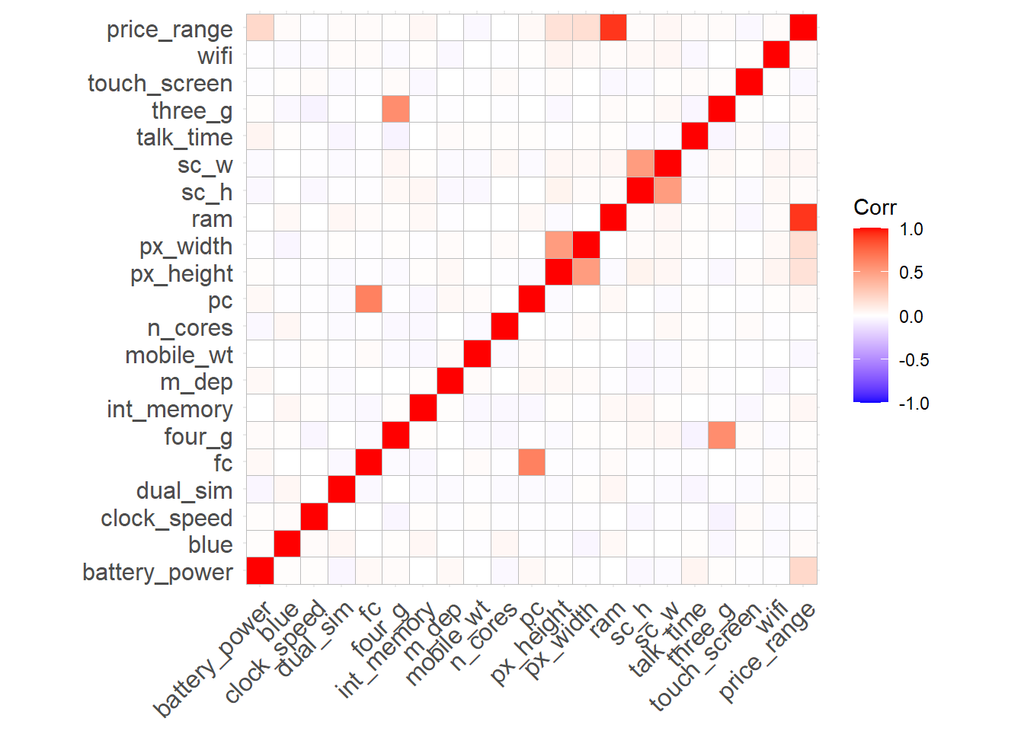

```r
corr <- round(cor(org_data), 8)
ggcorrplot(corr)
```

**3.1 Univariate Data Analysis**

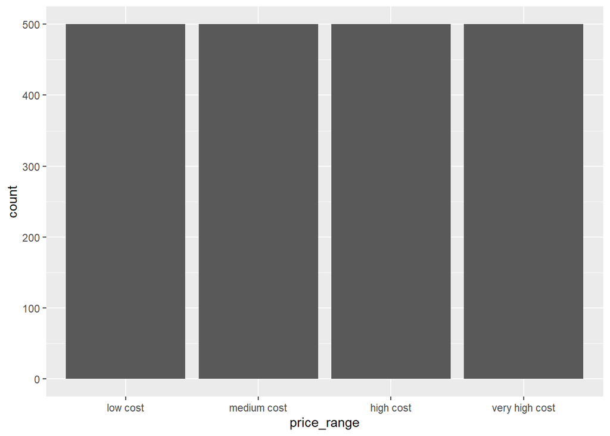

```r
ggplot(data=data, aes(x = price_range)) +
  geom_bar()
```

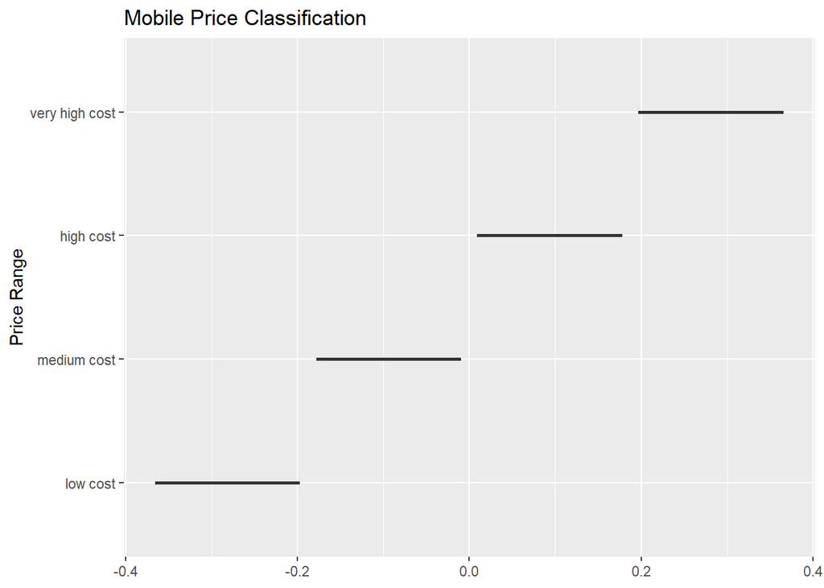

```r
ggplot(data = data, aes(y=price_range)) +
  geom_boxplot() +
  labs(title = "Mobile Price Classification", y="Price Range")
```

From the result above, we know the amount of data in dataset has the same amount in each class that consist of low cost, medium cost, high cost, and very high cost.

We can now create 3 Bar Plots by storing them in there different variables (p1, p2, p3) and then add them to **grid.arrange()** to create a subplot. In this case, I decided to examine the Bluetooth, Dual Sim and 4G features. As we can see below, a slight majority of mobiles considered in this Dataset does not support Bluetooth, is Dual Sim and has 4G support.

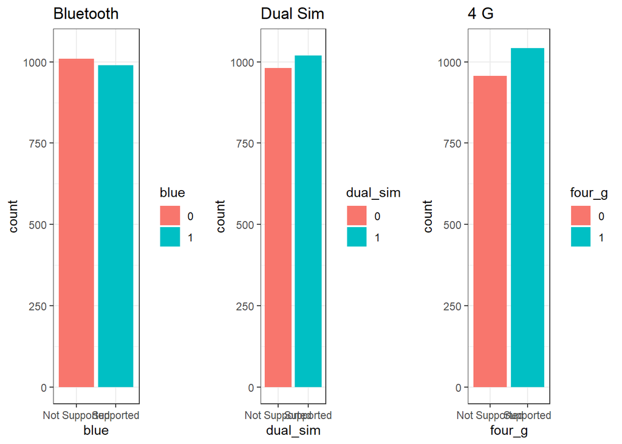

```r
# Bar Chart Subplots
p1 <-  ggplot(data, aes(x=blue, fill=blue)) +
  theme_bw() +
  geom_bar() +
  ylim(0, 1050) +
  labs(title = "Bluetooth") +
  scale_x_discrete(labels = c('Not Supported','Supported'))
p2 <- ggplot(data, aes(x=dual_sim, fill=dual_sim)) +
  theme_bw() +
  geom_bar() +
  ylim(0, 1050) +
  labs(title = "Dual Sim") +
  scale_x_discrete(labels = c('Not Supported','Supported'))
p3 <- ggplot(data, aes(x=four_g, fill=four_g)) +
  theme_bw() +
  geom_bar() +
  ylim(0, 1050) +
  labs(title = "4 G") +
  scale_x_discrete(labels = c('Not Supported','Supported'))
grid.arrange(p1, p2, p3, nrow = 1)
```

Taking our analysis a step further, we can now calculate the precise percentages of the difference between the different cases using the **prop.table()** function. As we can see from the resulting output (Figure 7), 50.5% of the considered mobile devices do not support Bluetooth, 50.9% is Dual Sim and 52.1% has 4G.

```r
prop.table(table(data$blue)) # cell percentages
```

```
##
##     0     1
## 0.505 0.495
```

```r
prop.table(table(data$dual_sim)) # cell percentages
```

```
##
##      0      1
## 0.4905 0.5095
```

```r
prop.table(table(data$four_g)) # cell percentages
```

```
##
##      0      1
## 0.4785 0.5215
```

**3.2 Bivariate Data Analysis**

Analysis of two variables, We can find out some relation between features of mobile phone and its selling price.

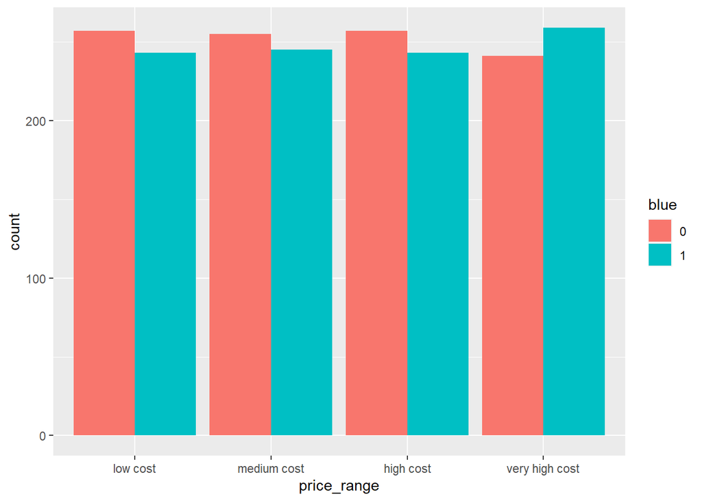

```r
ggplot(data, aes(x=price_range, fill = blue)) +
  geom_bar(position = "dodge")
```

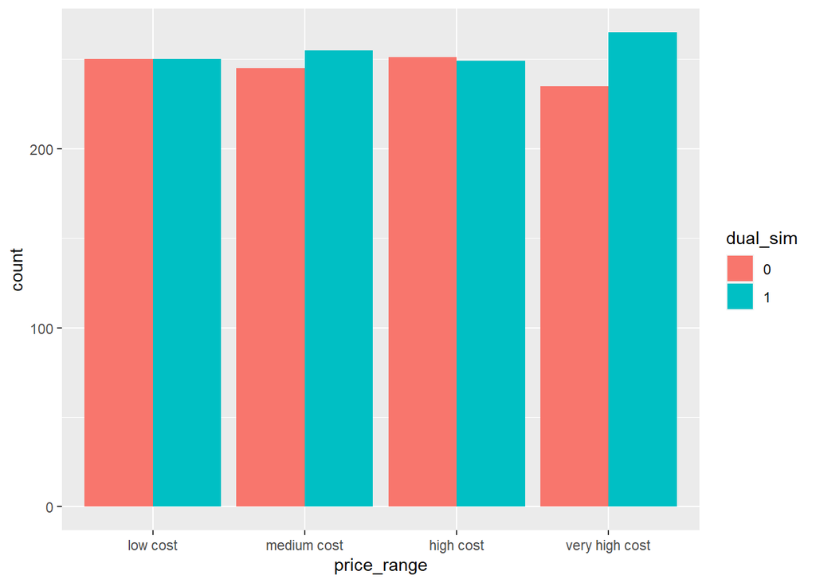

```r
ggplot(data, aes(x=price_range, fill = dual_sim)) +
  geom_bar(position = "dodge")
```

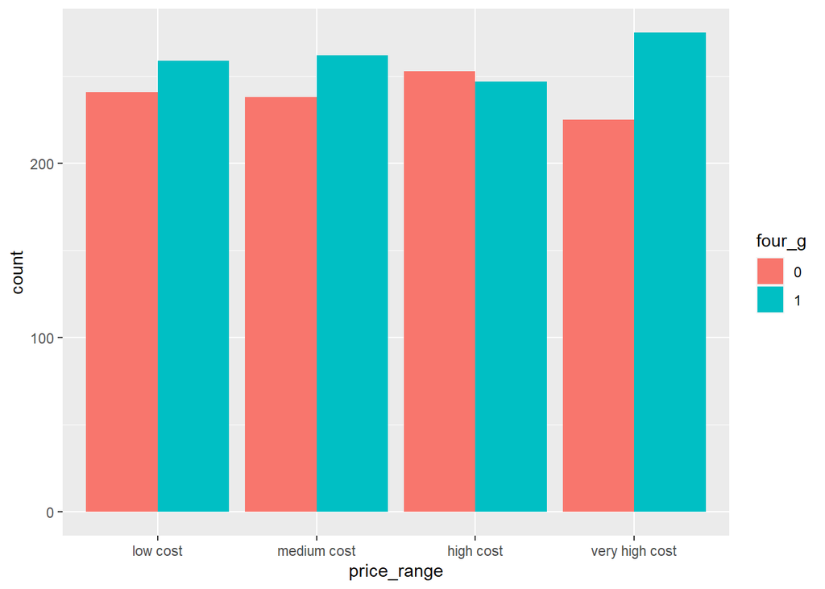

```r
ggplot(data, aes(x=price_range, fill = four_g)) +
  geom_bar(position = "dodge")
```

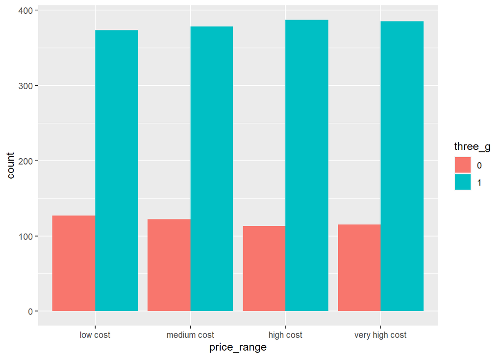

```r
ggplot(data, aes(x=price_range, fill = three_g)) +
  geom_bar(position = "dodge")
```

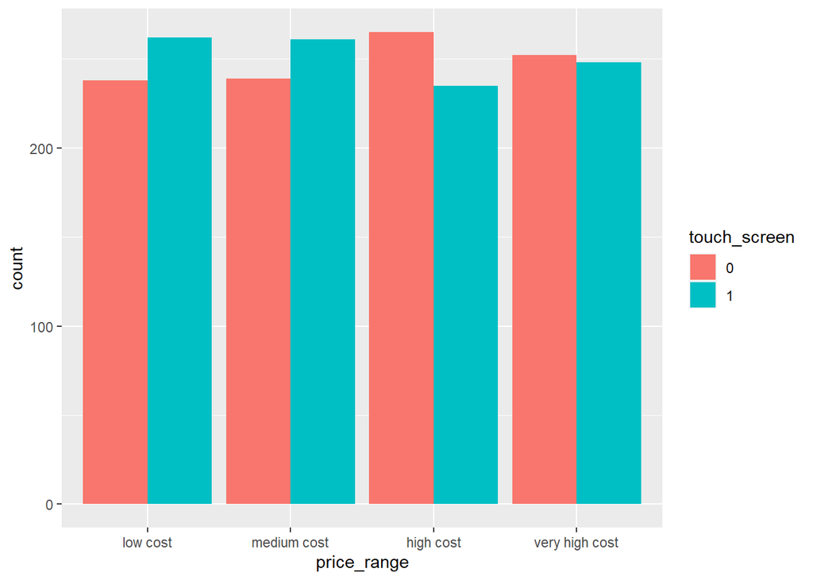

```r
ggplot(data, aes(x=price_range, fill = touch_screen)) +
  geom_bar(position = "dodge")
```

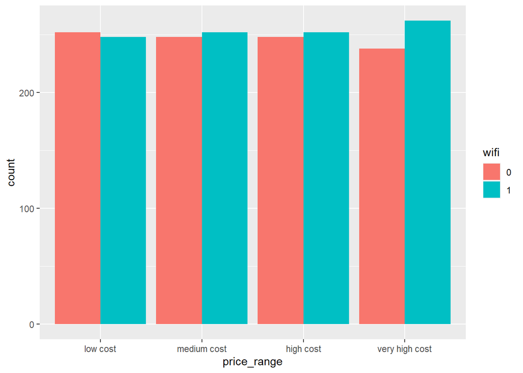

```r
ggplot(data, aes(x=price_range, fill = wifi)) +
  geom_bar(position = "dodge")
```

We can now go on creating 3 different Box Plots using the same technique used before. In this case, I decided to examine how having more battery power, phone weight and RAM (Random Access Memory) can affect mobiles prices. In this Dataset, we are not given the actual phone prices but a price range indicating how high the price is (four different levels from 0 to 3).

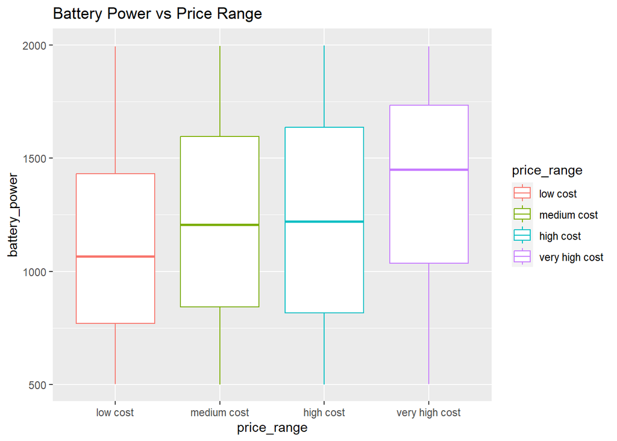

```r
# Bar Chart Subplots
p1 <-  ggplot(data, aes(x=price_range, y = battery_power, color=price_range)) +
  geom_boxplot(outlier.colour="red", outlier.shape=8,
               outlier.size=4) +
  labs(title = "Battery Power vs Price Range")
p2 <- ggplot(data, aes(x=price_range, y = mobile_wt, color=price_range)) +
  geom_boxplot(outlier.colour="red", outlier.shape=8,
               outlier.size=4) +
  labs(title = "Phone Weight vs Price Range")
p3 <- ggplot(data, aes(x=price_range, y = ram, color=price_range)) +
  geom_boxplot(outlier.colour="red", outlier.shape=8,
               outlier.size=4) +
  labs(title = "RAM vs Price Range")
p1
```

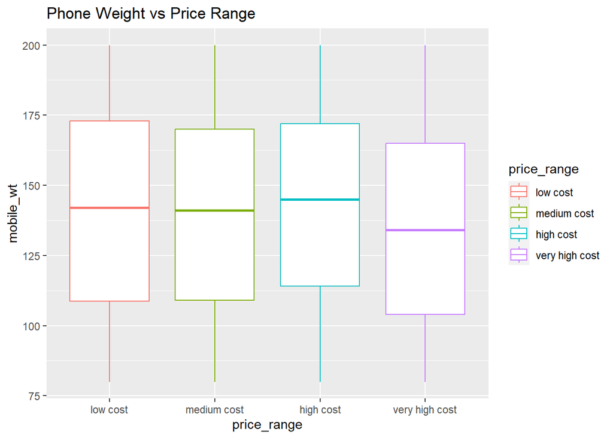

```r
p2
```

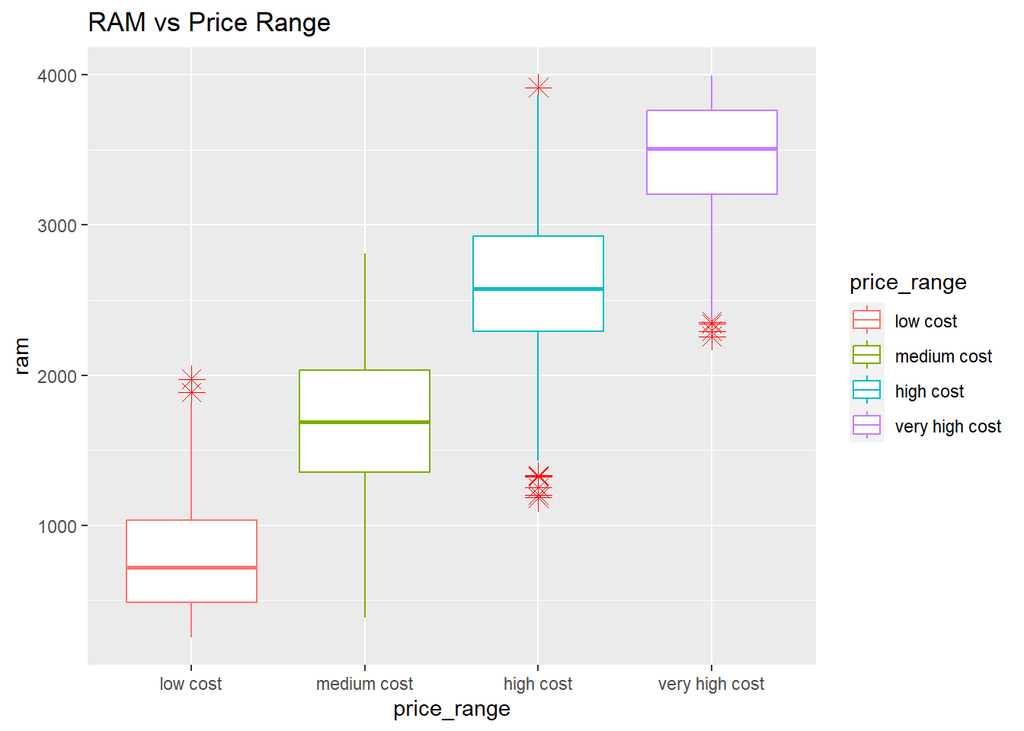

```r
p3
```

Increasing Battery Power and RAM consistently lead to an increase in Price. Instead, more expensive phones seem to be overall more lightweight. In the RAM vs Price Range plot have interestingly been registred some outliers values in the overall distribution.

Observations based on **ram** and **cores** variables. We need to know whether the number of ram and cores can affect the price. The color and shape of the observations are based on selling price (low cost, medium cost, high cost, and very high cost).

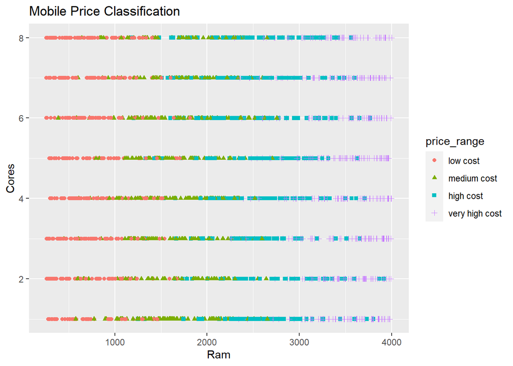

```r
ggplot(data=data, aes(x=ram, y=n_cores,
                        shape=price_range, color=price_range)) +
  geom_point() +
  labs(title = "Mobile Price Classification", x="Ram", y="Cores")
```

## **4. Modelling**

Now, let’s use **Linear Regression** to try and predict price range. First, we’ll use only the most correlated variable to price range which is ram.

```r
mymodel_fit1 = lm(price_range~ram, data=org_data)

summary(mymodel_fit1)
```

```
##
## Call:
## lm(formula = price_range ~ ram, data = org_data)
##
## Residuals:
##      Min       1Q   Median       3Q      Max
## -1.35798 -0.26945 -0.00074  0.25969  1.38797
##
## Coefficients:
##               Estimate Std. Error t value Pr(>|t|)
## (Intercept) -5.083e-01  2.194e-02  -23.17   <2e-16 ***
## ram          9.454e-04  9.198e-06  102.79   <2e-16 ***
## ---
## Signif. codes:  0 '***' 0.001 '**' 0.01 '*' 0.05 '.' 0.1 ' ' 1
##
## Residual standard error: 0.4461 on 1998 degrees of freedom
## Multiple R-squared:  0.841,  Adjusted R-squared:  0.8409
## F-statistic: 1.057e+04 on 1 and 1998 DF,  p-value: < 2.2e-16
```

Our results from our linear regression model are pretty good -- our variable is statistically signifcant (as expected) but beyond that, our r squared value is 0.84 (**84%**)

Does adding battery_power (the second most correlated variable to price range) to the mix improve our model?

```r
mymodel_fit2 = lm(price_range~ram+battery_power, data=org_data)

summary(mymodel_fit2)
```

```
##
## Call:
## lm(formula = price_range ~ ram + battery_power, data = org_data)
##
## Residuals:
##      Min       1Q   Median       3Q      Max
## -1.05745 -0.27597 -0.01211  0.24860  1.24268
##
## Coefficients:
##                 Estimate Std. Error t value Pr(>|t|)
## (Intercept)   -1.143e+00  3.080e-02  -37.11   <2e-16 ***
## ram            9.456e-04  7.942e-06  119.07   <2e-16 ***
## battery_power  5.124e-04  1.960e-05   26.14   <2e-16 ***
## ---
## Signif. codes:  0 '***' 0.001 '**' 0.01 '*' 0.05 '.' 0.1 ' ' 1
##
## Residual standard error: 0.3852 on 1997 degrees of freedom
## Multiple R-squared:  0.8815, Adjusted R-squared:  0.8814
## F-statistic:  7428 on 2 and 1997 DF,  p-value: < 2.2e-16
```

Yes, it improves our model! Can we improve our model even further by adding the third most correlated variable to price range (px_height)?

```r
mymodel_fit3 = lm(price_range~ram+battery_power+px_height, data=org_data)

summary(mymodel_fit3)
```

```
##
## Call:
## lm(formula = price_range ~ ram + battery_power + px_height, data = org_data)
##
## Residuals:
##      Min       1Q   Median       3Q      Max
## -0.97609 -0.26184 -0.00464  0.24232  0.87833
##
## Coefficients:
##                 Estimate Std. Error t value Pr(>|t|)
## (Intercept)   -1.410e+00  2.921e-02  -48.29   <2e-16 ***
## ram            9.490e-04  6.978e-06  136.00   <2e-16 ***
## battery_power  5.061e-04  1.722e-05   29.38   <2e-16 ***
## px_height      4.149e-04  1.706e-05   24.32   <2e-16 ***
## ---
## Signif. codes:  0 '***' 0.001 '**' 0.01 '*' 0.05 '.' 0.1 ' ' 1
##
## Residual standard error: 0.3384 on 1996 degrees of freedom
## Multiple R-squared:  0.9086, Adjusted R-squared:  0.9085
## F-statistic:  6613 on 3 and 1996 DF,  p-value: < 2.2e-16
```

We get an R squared value of 0.91, which is **91%** (out of 100). This result is very good, and it means our Linear Regression Model performed very well.

## **conclusion**

But wait a second... we’re using a regression model on a classification problem. Why does this work? Well because our y variable will either be 0, 1, 2, or 3 our model treats it as if it is regression and runs. Moreover, it performs well because it evaluates our 4 categories (above) as quantitative variables (not qualitative) and uses linear regression to find the optimal price range for each observation, which is then classified into 0, 1, 2, or 3.

**Addressing our central question: Which features are most important in predicting a Mobile Phone’s Price?**

First, looking at our correlation matrix we see that ram is the most correlated variable to price range, battery power is the second most correlated variable to price range, and px height is the third most correlated variable to price range.

Now, looking at the summary of our Linear Regression Model, we see that all 3 variables (ram, battery power, and px height) have very high t-values meaning that they are all very important in predicting our y-variable. Specifically, ram has the highest t-value, battery power has the second highest t-value, and px height has the third highest t-value. This “order of variable importance” directly corresponds to our findings from our correlation matrix above!

**In conclusion, the most important features in predicting a Mobile Phone’s price are ram, battery power, and pixel height.**